# Regressão Linear Simples

# Modelo de Regressão Linear Simples

Considerando as insformações de idade e custo de uma pessoa em uma empresa de plano de saúde.

```r
library(tidyverse)
idade <- c(18,23,28,33,38,43,48,53,58,63)
custo <- c(871,1132,1242,1356,1488,1638,2130,2454,3066,4090)
dados <- data.frame(idade,custo)
dados
```

| idade | custo |
| --- | --- |
| 18 | 871 |
| 23 | 1132 |
| 28 | 1242 |
| 33 | 1356 |
| 38 | 1488 |
| 43 | 1638 |
| 48 | 2130 |
| 53 | 2454 |
| 58 | 3066 |
| 63 | 4090 |

**Estimando os coeficientes por matrizes**

Imaginando que queremos o seguinte modelo

Yi = a + bXi + ei

sendo: custo = a + b*idade + e

Transformando em vetores e matrizes

```r
# criando matrizes e vetores
Y <- custo
is.vector(Y)
```

```
[1] TRUE
```

```r
X=cbind(1,idade)
is.matrix(X)
```

```
[1] TRUE
```

Criando a operação matricial

- t(x) -> transposta de X
- solve -> inversa
- %*% -> multiplicação

Chegamos aos betas

```r
solve(t(X)%*%X)%*%t(X)%*%Y
```

```
            [,1]
      -558.94909
idade   61.86788
```

Chegamos ao nosso modelo

custo = -558,94 + 61,86*idade

Geramos o modelo usando função lm Queremos prever o custo baseado na idade dos clientes Interceptação e Inclinação o quanto a variável depe. aumenta com o aumento da variavel indepenente

```r
modelo = lm(custo ~ idade, data=dados)
summary(modelo)
```

```
Call:
lm(formula = custo ~ idade, data = dados)

Residuals:
    Min      1Q  Median      3Q     Max
-463.37 -277.04  -45.04  218.15  751.27

Coefficients:
            Estimate Std. Error t value Pr(>|t|)
(Intercept) -558.949    368.759  -1.516    0.168
idade         61.868      8.582   7.209 9.16e-05 ***
---
Signif. codes:  0 ‘***’ 0.001 ‘**’ 0.01 ‘*’ 0.05 ‘.’ 0.1 ‘ ’ 1

Residual standard error: 389.7 on 8 degrees of freedom
Multiple R-squared:  0.8666,    Adjusted R-squared:  0.8499
F-statistic: 51.98 on 1 and 8 DF,  p-value: 9.161e-05
```

```r
shapiro.test(modelo$residuals)
```

```
    Shapiro-Wilk normality test

data:  modelo$residuals
W = 0.93552, p-value = 0.5043
```

Teste de Normalidade Shapiro- Wilk

- H0: X é normalmente distribuiído
- H1: X não é normalemnte distribuído

p-valor > 0,05 Não rejeitamos H0

Aplicando o teste de shapiro, NÃO rejeitamos a hipotese nula e podemos assumir a normalidade dos residuals pois p-value = 0.5043 .

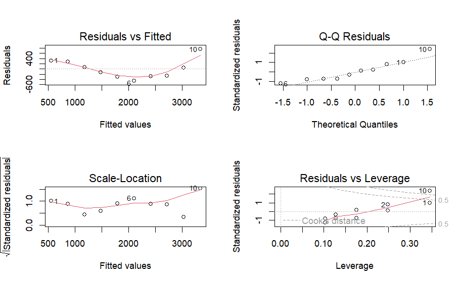

```r
par(mfrow = c(2,2))
plot(modelo)
```

Gráfico 1: Temos os resíduos em função dos valores estimados. Aqui observamos a independência e a homocedasticidade, se os resíduos se distribuem de maneira razoavelmente aleatória e com mesma amplitude em torno do zero.

Gráfico 2: Podemos avaliar a normalidade dos resíduos. A linha diagonal pontilhada representa a distribuição normal teórica, e os pontos a distribuição dos resíduos observada. Espera-se que não exista grande fuga dos pontos em relação à reta.

Gráfico 3: Pode ser avaliado da mesma maneira que o primeiro, observando a aleatoriedade e amplitude, desta vez dos resíduos padronizados.

Gráfico 4: E o último gráfico permite visualizar as Distâncias de Cook das observações, uma medida de influência que pode indicar a presença de outliers quando possui valor maior do que 1.